# Forecasting U.S. Retail Sales (MRTSSM44000USN) - Final Project

Claudia Toto

11/17/2026

# 1. The Problem

The goal is to forecast **monthly U.S. retail sales** for the next 12 months. Retail sales account for a large share of consumer spending, so an accurate forecast helps businesses plan inventory, staffing and cash flow, especially for the holiday season, and works as an early signal of the overall economy.

# 2. The Data

```r
library(fpp2)
library(forecast)
library(readxl)

data_check <- read_excel("MRTSSM44000USN.xlsx", sheet = "Monthly")
head(data_check)
```

```
## # A tibble: 6 × 2
##   observation_date    MRTSSM44000USN
##   <dttm>                       <dbl>
## 1 1992-01-01 00:00:00         126717
## 2 1992-02-01 00:00:00         127022
## 3 1992-03-01 00:00:00         137978
## 4 1992-04-01 00:00:00         142314
## 5 1992-05-01 00:00:00         147550
## 6 1992-06-01 00:00:00         146991
```

```r
sales_ts <- ts(data_check$MRTSSM44000USN, start = c(1992, 1), frequency = 12)
summary(sales_ts)
```

```
##    Min. 1st Qu.  Median    Mean 3rd Qu.    Max.
##  126717  238489  322076  344399  414180  716924
```

**Source:** FRED (Federal Reserve Bank of St. Louis), series MRTSSM44000USN, originally published by the U.S. Census Bureau (Monthly Retail Trade Survey). Monthly retail trade sales in millions of dollars, **not seasonally adjusted**, January 1992 to July 2026 (415 observations).

**Reliability:** it is an official government statistic, collected with a consistent methodology for more than 30 years, with no missing values.

# 3. Methodology

```r
# Train: Jan 1992 - Jul 2025 | Test: last 12 months, Aug 2025 - Jul 2026
train <- window(sales_ts, end = c(2025, 7))
test  <- window(sales_ts, start = c(2025, 8))
h <- length(test)
length(train); length(test)
```

```
## [1] 403
```

```
## [1] 12
```

Seven models from the course are compared: **Mean, Naive, Seasonal Naive, ETS, Holt-Winters, STL and ARIMA**. Each model is fitted on the training data (Jan 1992 – Jul 2025) and used to forecast the last 12 months (Aug 2025 – Jul 2026), which the model has never seen. The forecasts are compared with the actual values.

**Accuracy measure: MAPE** (Mean Absolute Percentage Error) on the test set. MAPE expresses the error as a percentage, so it is easy to interpret and to compare across models. RMSE and MASE are also reported as support.

# 4. Exploration

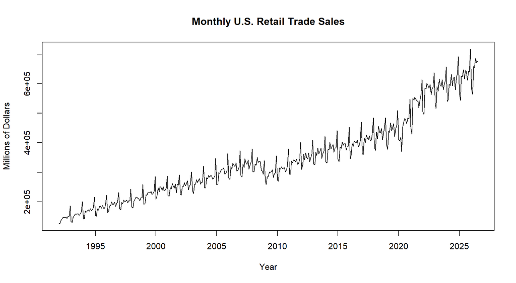

```r
plot(sales_ts, main = "Monthly U.S. Retail Trade Sales", xlab = "Year", ylab = "Millions of Dollars")
```

**Insight:** strong upward trend, from about $127 billion per month in 1992 to about $677 billion in 2026. There is a clear repeating yearly pattern, a drop in 2008–2009 (financial crisis) and a sharp drop in April 2020 (COVID) followed by a fast recovery. The size of the seasonal swings grows as sales grow.

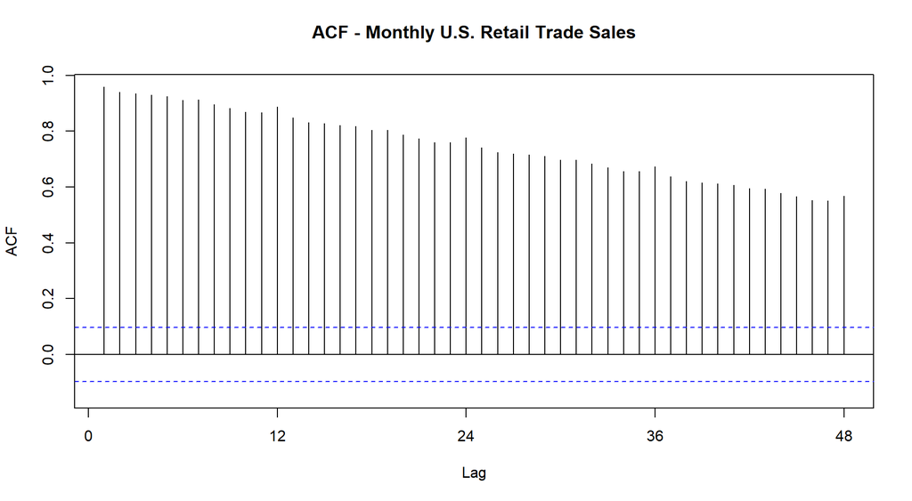

```r
Acf(sales_ts, lag.max = 48, main = "ACF - Monthly U.S. Retail Trade Sales")
```

**Insight:** the autocorrelations are very high and decay slowly, which confirms a strong trend (the series is not stationary). The bumps at lags 12, 24 and 36 confirm the yearly seasonality.

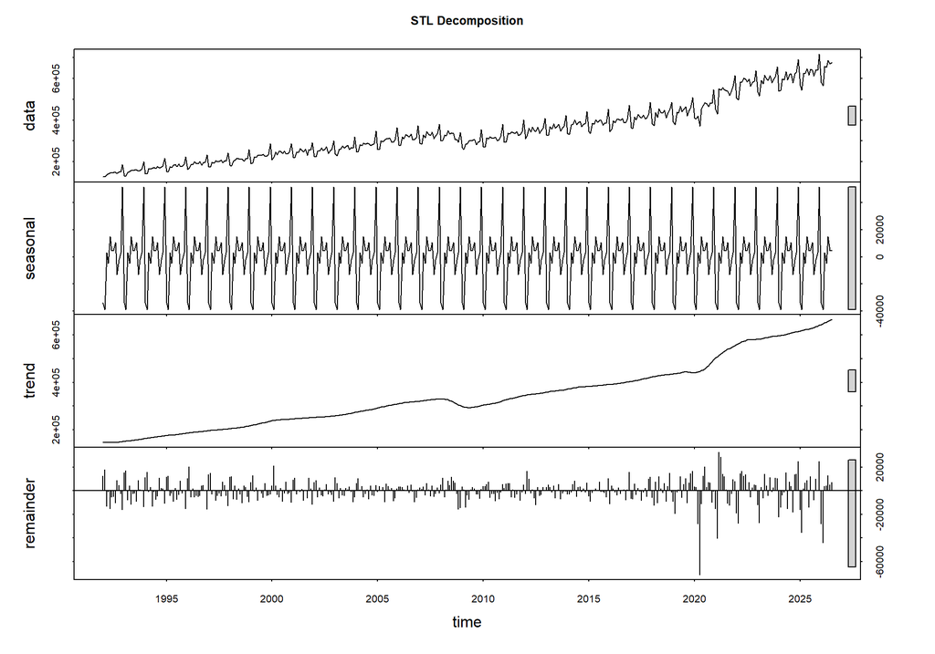

```r
stl_decomp <- stl(sales_ts, s.window = "periodic")
plot(stl_decomp, main = "STL Decomposition")
```

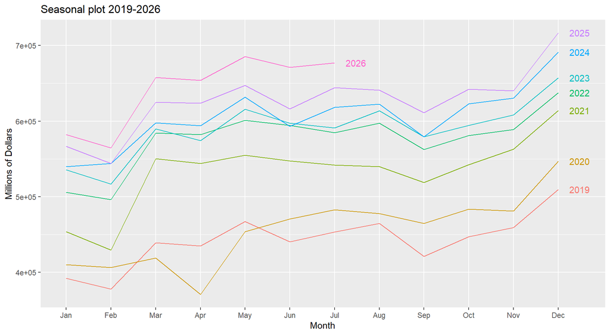

```r
ggseasonplot(window(sales_ts, start = 2019), year.labels = TRUE) +
  ggtitle("Seasonal plot 2019-2026") + ylab("Millions of Dollars")
```

# 5. Judgement: Models

```r
mean_fc   <- meanf(train, h = h)
naive_fc  <- naive(train, h = h)
snaive_fc <- snaive(train, h = h)

ets_model <- ets(train)
ets_fc    <- forecast(ets_model, h = h)

HW_model  <- HoltWinters(train)
HW_fc     <- forecast(HW_model, h = h)

stl_train <- stl(train, s.window = "periodic")
stl_fc    <- forecast(stl_train, h = h)

arima_model <- auto.arima(train, stepwise = FALSE)
arima_fc    <- forecast(arima_model, h = h)

ets_model
```

```
## ETS(M,Ad,M)
##
## Call:
## ets(y = train)
##
##   Smoothing parameters:
##     alpha = 0.4715
##     beta  = 0.0168
##     gamma = 0.1628
##     phi   = 0.98
##
##   Initial states:
##     l = 138037.1442
##     b = 1382.9422
##     s = 1.2187 1.006 0.9902 0.959 1.0144 0.9997
##            1.0123 1.0313 0.9918 0.9951 0.8862 0.8952
##
##   sigma:  0.0253
##
##      AIC     AICc      BIC
## 9663.644 9665.425 9735.625
```

```r
arima_model
```

```
## Series: train
## ARIMA(4,1,0)(0,1,1)[12]
##
## Coefficients:
##           ar1      ar2      ar3      ar4     sma1
##       -0.3124  -0.3491  -0.0208  -0.2067  -0.7034
## s.e.   0.0500   0.0522   0.0529   0.0497   0.0345
##
## sigma^2 = 90866211:  log likelihood = -4128.55
## AIC=8269.1   AICc=8269.32   BIC=8292.9
```

## Accuracy on the test set

```r
models <- list("Mean" = mean_fc, "Naive" = naive_fc, "Seasonal Naive" = snaive_fc,
               "ETS" = ets_fc, "Holt-Winters" = HW_fc, "STL" = stl_fc, "ARIMA" = arima_fc)

for (m in names(models)) { cat("\n--", m, "--\n"); print(accuracy(models[[m]], test)) }
```

```
##
## -- Mean --
##                        ME     RMSE      MAE       MPE     MAPE      MASE
## Training set 2.846981e-11 130561.9 104509.4 -16.71234 36.96845  5.996528
## Test set     3.098983e+05 312622.5 309898.3  47.80184 47.80184 17.781302
##                    ACF1 Theil's U
## Training set 0.95555934        NA
## Test set     0.08878939  5.562954
##
## -- Naive --
##                     ME     RMSE      MAE        MPE     MAPE     MASE
## Training set 1288.0000 34247.73 22899.88 -0.1271194 7.033168 1.313946
## Test set      843.1667 41189.54 31745.17 -0.2908393 5.015810 1.821470
##                     ACF1 Theil's U
## Training set -0.35814319        NA
## Test set      0.08878939 0.7694372
##
## -- Seasonal Naive --
##                    ME     RMSE      MAE      MPE     MAPE     MASE      ACF1
## Training set 14467.61 23833.86 17428.32 4.221573 5.184953 1.000000 0.7834566
## Test set     27575.75 29909.50 27575.75 4.237838 4.237838 1.582238 0.4022183
##              Theil's U
## Training set        NA
## Test set     0.5399336
##
## -- ETS --
##                      ME      RMSE       MAE       MPE     MAPE      MASE
## Training set   785.9039  9614.612  6175.006 0.2111225 1.793151 0.3543087
## Test set     14857.1228 17956.535 15436.018 2.2549502 2.345289 0.8856858
##                    ACF1 Theil's U
## Training set 0.08036497        NA
## Test set     0.47484528 0.3261674
##
## -- Holt-Winters --
##                      ME     RMSE       MAE        MPE     MAPE      MASE
## Training set   499.7624  9780.71  6471.198 0.03019943 1.888571 0.3713036
## Test set     10193.0168 14927.22 11884.800 1.49303058 1.784505 0.6819245
##                    ACF1 Theil's U
## Training set 0.07852243        NA
## Test set     0.24593785 0.2706117
##
## -- STL --
##                    ME     RMSE       MAE       MPE     MAPE      MASE      ACF1
## Training set 1006.453 11448.88  8046.062 0.2632869 2.639823 0.4616659 0.1906805
## Test set     7147.116 21120.08 18173.710 0.9119605 2.828244 1.0427688 0.2227103
##              Theil's U
## Training set        NA
## Test set     0.3945264
##
## -- ARIMA --
##                     ME      RMSE      MAE         MPE     MAPE      MASE
## Training set  254.0917  9317.063 6191.174 0.005333306 1.787995 0.3552364
## Test set     2925.8449 11124.228 9750.097 0.361560495 1.506331 0.5594398
##                      ACF1 Theil's U
## Training set -0.007904874        NA
## Test set      0.255500164 0.1986039
```

```r
acc_table <- t(sapply(models, function(f) accuracy(f, test)["Test set", c("RMSE", "MAE", "MAPE", "MASE")]))
round(acc_table[order(acc_table[, "MAPE"]), ], 3)
```

```
##                     RMSE        MAE   MAPE   MASE
## ARIMA           11124.23   9750.097  1.506  0.559
## Holt-Winters    14927.22  11884.800  1.785  0.682
## ETS             17956.53  15436.018  2.345  0.886
## STL             21120.08  18173.710  2.828  1.043
## Seasonal Naive  29909.50  27575.750  4.238  1.582
## Naive           41189.54  31745.167  5.016  1.821
## Mean           312622.45 309898.256 47.802 17.781
```

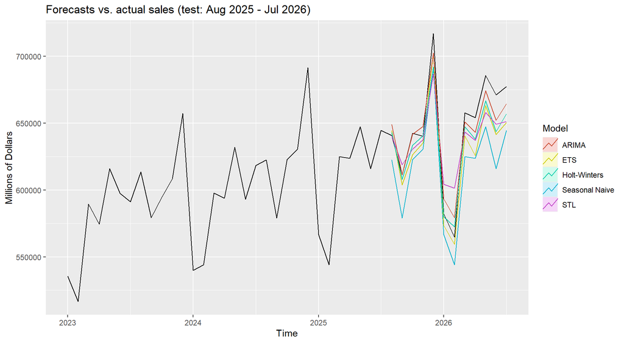

```r
autoplot(window(sales_ts, start = 2023)) +
  autolayer(snaive_fc, series = "Seasonal Naive", PI = FALSE) +
  autolayer(ets_fc,    series = "ETS",            PI = FALSE) +
  autolayer(HW_fc,     series = "Holt-Winters",   PI = FALSE) +
  autolayer(stl_fc,    series = "STL",            PI = FALSE) +
  autolayer(arima_fc,  series = "ARIMA",          PI = FALSE) +
  ggtitle("Forecasts vs. actual sales (test: Aug 2025 - Jul 2026)") +
  ylab("Millions of Dollars") + guides(colour = guide_legend(title = "Model"))
```

## Residual analysis

A good model leaves residuals that look like white noise: centered at 0, no significant autocorrelation, and a **Ljung-Box p-value > 0.05**.

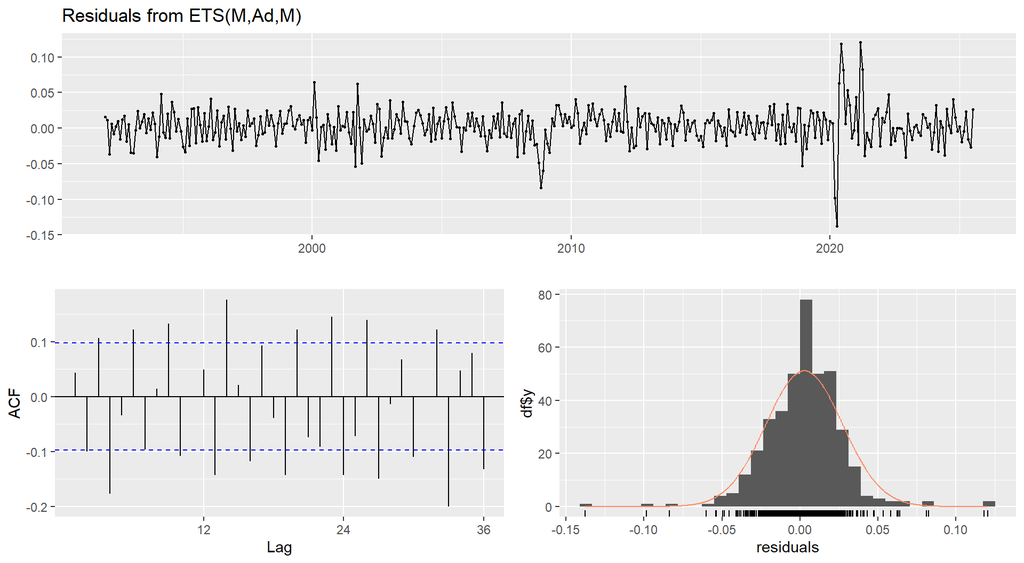

```
##
##  Ljung-Box test
##
## data:  Residuals from ETS(M,Ad,M)
## Q* = 117.02, df = 24, p-value = 3.286e-14
##
## Model df: 0.   Total lags used: 24
```

```r
checkresiduals(ets_fc)
```

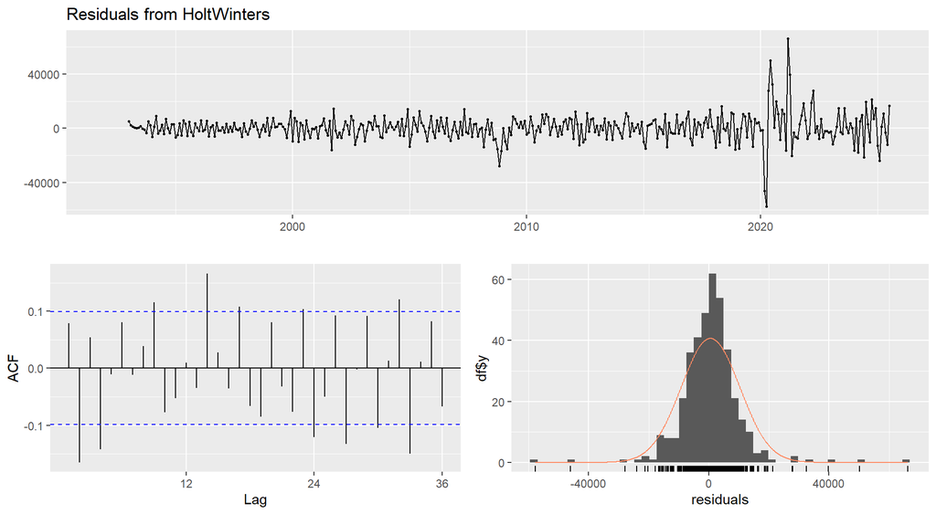

```
##
##  Ljung-Box test
##
## data:  Residuals from HoltWinters
## Q* = 72.919, df = 24, p-value = 7.832e-07
##
## Model df: 0.   Total lags used: 24
```

```r
checkresiduals(HW_fc)
```

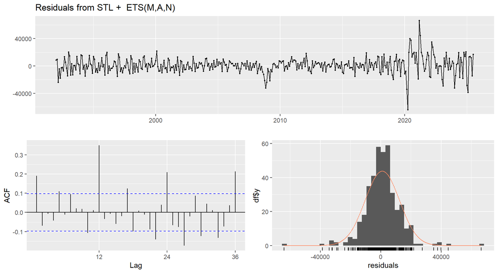

```
##
##  Ljung-Box test
##
## data:  Residuals from STL +  ETS(M,A,N)
## Q* = 127.42, df = 24, p-value = 4.441e-16
##
## Model df: 0.   Total lags used: 24
```

```r
checkresiduals(stl_fc)
```

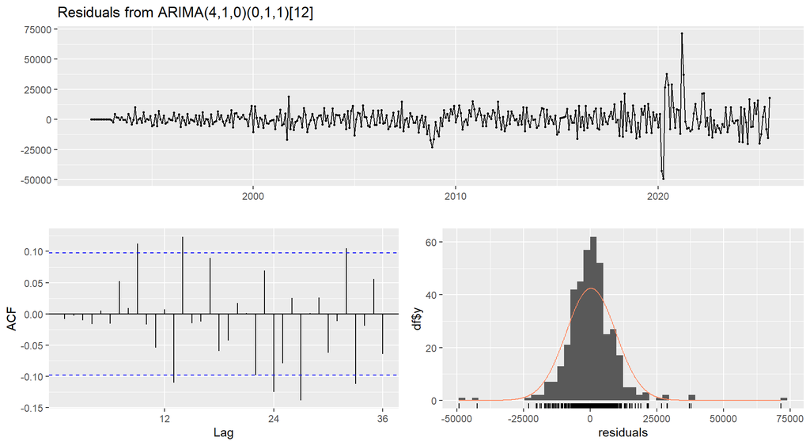

```
##
##  Ljung-Box test
##
## data:  Residuals from ARIMA(4,1,0)(0,1,1)[12]
## Q* = 38.301, df = 19, p-value = 0.005433
##
## Model df: 5.   Total lags used: 24
```

```r
checkresiduals(arima_fc)
```